**Title**: Data Science Coursera Machine Learning Assignment

**Topic:** Predicting Exercise Behavior

**Author:** Amlan Nanda

**Executive Summary**

One thing that people regularly do is quantify how much of a particular activity they do, but they rarely quantify how well they do it. In this project, our goal will be to use data from accelerometers on the belt, forearm, arm, and dumbell of 6 participants and predict the manner in which they did the exercise

**Pre-processing**:

Load the libraries and the data and view the structure of the training data

```r
library(caret)
```

```r
library(rpart)
library(rpart.plot)
library(rattle)
training<- read.csv("~/Documents/Data Science/RCodes/mo 8/Assignment/pml-training.csv",na.strings=c(NA, "NA",""))
testing <- read.csv("~/Documents/Data Science/RCodes/mo 8/Assignment/pml-testing.csv",na.strings=c(NA, "NA",""))
str(training)
```

```
## 'data.frame':    19622 obs. of  160 variables:
##  $ X                       : int  1 2 3 4 5 6 7 8 9 10 ...
##  $ user_name               : Factor w/ 6 levels "adelmo","carlitos",..: 2 2 2 2 2 2 2 2 2 2 ...
##  $ raw_timestamp_part_1    : int  1323084231 1323084231 1323084231 1323084232 1323084232 1323084232 1323084232 1323084232 1323084232 1323084232 ...
##  $ raw_timestamp_part_2    : int  788290 808298 820366 120339 196328 304277 368296 440390 484323 484434 ...
##  $ cvtd_timestamp          : Factor w/ 20 levels "02/12/2011 13:32",..: 9 9 9 9 9 9 9 9 9 9 ...
##  $ new_window              : Factor w/ 2 levels "no","yes": 1 1 1 1 1 1 1 1 1 1 ...
##  $ num_window              : int  11 11 11 12 12 12 12 12 12 12 ...
##  $ roll_belt               : num  1.41 1.41 1.42 1.48 1.48 1.45 1.42 1.42 1.43 1.45 ...
##  $ pitch_belt              : num  8.07 8.07 8.07 8.05 8.07 8.06 8.09 8.13 8.16 8.17 ...
##  $ yaw_belt                : num  -94.4 -94.4 -94.4 -94.4 -94.4 -94.4 -94.4 -94.4 -94.4 -94.4 ...
##  $ total_accel_belt        : int  3 3 3 3 3 3 3 3 3 3 ...
##  $ kurtosis_roll_belt      : Factor w/ 396 levels "-0.016850","-0.021024",..: NA NA NA NA NA NA NA NA NA NA ...
##  $ kurtosis_picth_belt     : Factor w/ 316 levels "-0.021887","-0.060755",..: NA NA NA NA NA NA NA NA NA NA ...
##  $ kurtosis_yaw_belt       : Factor w/ 1 level "#DIV/0!": NA NA NA NA NA NA NA NA NA NA ...
```

[output cut: 86 more lines]

We select relevant columns pertaining to predictors we want:

```r
index <- grep("classe|belt|arm|dumbbell|forearm", names(training))
training<-training[,index]

index1 <- grep("classe|belt|arm|dumbbell|forearm", names(testing))
testing<-testing[,index]
```

We will then remove columns with missing values:

```r
training <- training[, colSums(is.na(training)) == 0]
testing <- testing[, colSums(is.na(testing)) == 0]
```

The test set contains a lot of NAs. We will remov rows with NAs to improve the accuracy:

```r
training <- training[complete.cases(training),] #406 obs of 111 variables
```

Since there is no ‘classe’ variable in the testing dataset, we’ll have to use the training set for cross-validation and calculate out of sample error rate. We’ll now split the training data set into train & test, with 80% data in training:

```r
set.seed(4200)
inTrain <- createDataPartition(training$classe,p=0.8,list=FALSE)
train.training<-training[inTrain,]
test.training <-training[-inTrain,]
```

**ModelFit**:

We will use try the model fit with both rpart and Random Forest.

```r
fit.rpart <- train(classe~., data = train.training, method= "rpart")
fit.rpart
```

```
## CART
##
## 15699 samples
##    52 predictor
##     5 classes: 'A', 'B', 'C', 'D', 'E'
##
## No pre-processing
## Resampling: Bootstrapped (25 reps)
## Summary of sample sizes: 15699, 15699, 15699, 15699, 15699, 15699, ...
## Resampling results across tuning parameters:
##
##   cp          Accuracy   Kappa       Accuracy SD  Kappa SD
##   0.02545616  0.5750856  0.45856812  0.02698711   0.03983590
##   0.04145972  0.4693322  0.29980726  0.07728179   0.13125938
##   0.11446373  0.3335567  0.07441319  0.04061390   0.06205409
##
## Accuracy was used to select the optimal model using  the largest value.
## The final value used for the model was cp = 0.02545616.
```

```r
rpart.results <- fit.rpart$results
round(max(rpart.results$Accuracy),4)
```

```
## [1] 0.5751
```

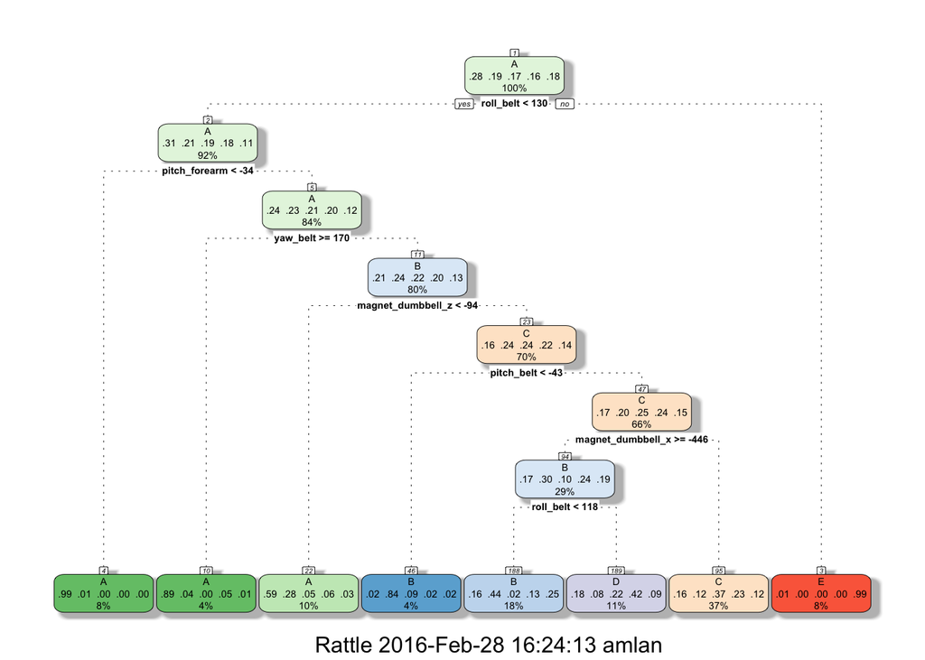

```r
fancyRpartPlot(fit.rpart$finalModel)
```

```r
ctrl <- trainControl(method = "cv", number = 4, allowParallel = TRUE)
fit.rf <- train(classe~., data = train.training, method= "rf",trControl=ctrl,prof=TRUE)
fit.rf
```

```
## Random Forest
##
## 15699 samples
##    52 predictor
##     5 classes: 'A', 'B', 'C', 'D', 'E'
##
## No pre-processing
## Resampling: Cross-Validated (4 fold)
## Summary of sample sizes: 11775, 11773, 11774, 11775
## Resampling results across tuning parameters:
##
##   mtry  Accuracy   Kappa      Accuracy SD   Kappa SD
##    2    0.9914011  0.9891212  0.0021439015  0.002712267
##   27    0.9912098  0.9888803  0.0013866612  0.001754923
##   52    0.9887890  0.9858179  0.0008071087  0.001021913
##
## Accuracy was used to select the optimal model using  the largest value.
## The final value used for the model was mtry = 2.
```

```r
rf.results <- fit.rf$results
round(max(rf.results$Accuracy),4)
```

```
## [1] 0.9914
```

While the accurarcy for the rpart was pretty low (0.5751), it improved to 0.9914 with the Random Forest method.We will use that model for calculating the out of sample error rates.

**Cross Validation and Out of Sample Error Rates**:

We will use the Random Forest model to predict the outcome for the test data.

```r
pRF <- predict(fit.rf,test.training)
confusionMatrix(pRF,test.training$classe)
```

```
## Confusion Matrix and Statistics
##
##           Reference
## Prediction    A    B    C    D    E
##          A 1114    3    0    0    0
##          B    2  756    3    0    0
##          C    0    0  681   12    0
##          D    0    0    0  631    4
##          E    0    0    0    0  717
##
## Overall Statistics
##
##                Accuracy : 0.9939
##                  95% CI : (0.9909, 0.9961)
##     No Information Rate : 0.2845
##     P-Value [Acc > NIR] : < 2.2e-16
##
##                   Kappa : 0.9923
##  Mcnemar's Test P-Value : NA
##
## Statistics by Class:
##
##                      Class: A Class: B Class: C Class: D Class: E
## Sensitivity            0.9982   0.9960   0.9956   0.9813   0.9945
## Specificity            0.9989   0.9984   0.9963   0.9988   1.0000
## Pos Pred Value         0.9973   0.9934   0.9827   0.9937   1.0000
## Neg Pred Value         0.9993   0.9991   0.9991   0.9964   0.9988
## Prevalence             0.2845   0.1935   0.1744   0.1639   0.1838
## Detection Rate         0.2840   0.1927   0.1736   0.1608   0.1828
## Detection Prevalence   0.2847   0.1940   0.1767   0.1619   0.1828
## Balanced Accuracy      0.9986   0.9972   0.9960   0.9901   0.9972
```

The accuracy on the test set actually slightly improved to 0.9939. The out of sample error rate is ~0.006

**Predict Test Cases**:

We will use the RF model to predict test cases:

```r
predict(fit.rf,testing)
```

```
##  [1] B A B A A E D B A A B C B A E E A B B B
## Levels: A B C D E
```